## Machine Learning Course Project

### Introduction

Through devices such as Jawbone Up, Nike FuelBand, and Fitbit it is possible to collect advantageous data regarding personal activity in a relatively inexpensive way. These devices are employed by people that wish to quantify self movement in order to assess their health and find behavioral patterns. Six individuals were asked to perform barbell lifts in 5 disctinct manners and the goal of the project is to understand the relationships between several variables that were investigated during the test. For more information please refer to the following website: http://groupware.les.inf.puc-rio.br/har.

### Step 1: Loading, cleaning and processing dataset

The *.csv files are loaded into R as data frames. The loading function also includes arguments that process factor type vectors and also manages the interpretation criteria for NA values. The first seven column vectors of the data frame correspond to information that does not reflect any measurement over the participant´s performance, hence they are removed from the training set. The data frame that will be used for the modelling process consists of 53 variables.

```r
raw_training<-read.csv("pml-training.csv",stringsAsFactors = FALSE,na.strings=c("NA",""))
testing<-read.csv("pml-testing.csv",stringsAsFactors = FALSE,na.strings=c("NA",""))
NA_columns<-apply(raw_training,2,function(x){sum(is.na(x))})
raw_training<-raw_training[,which(NA_columns==0)]
raw_training<-raw_training[,-c(1:7)]
```

### Step 2: Analysis of most relevant variables

In this section, the raw dataset is used to develop a model based on tree prediction. Upon this model, the most relevant variables are identified. Cross validation is used as a train control method for resampling.Parallel processing is introduced as an argument in the train control function

```r
library(caret)
library(rpart)
library(randomForest)
library(doParallel)
library(ggplot2)
trial_control<-trainControl(method="cv",number = 10,repeats = 3,allowParallel=TRUE)
trial_model<-train(classe ~., data=raw_training,method="rpart",trControl=trial_control)
var_hierarchy<-varImp(trial_model,scale=TRUE)
```

Every variable is given an importance score on the scale of 1 to 100. Only the variables with scores greater than 0 are selected for our model. This operation will surely reduce the computational time.

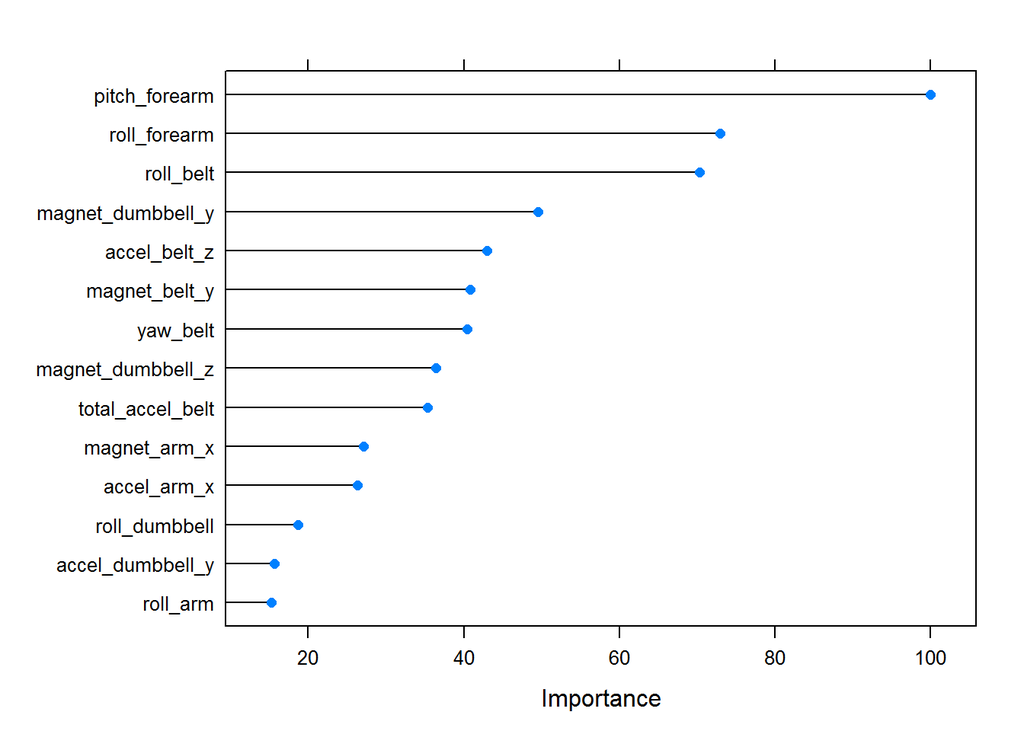

```r
training<-cbind(raw_training[,row.names(var_hierarchy$importance)[var_hierarchy$importance>0]],raw_training$classe)
colnames(training)[15]<-c("classe")
```

### Step 3: Data partition

The training data frame is divided in two subsets, sample train and test train.

```r
inTrain<-createDataPartition(y=training$classe, p=0.75, list=FALSE)
sample_train<-training[inTrain,]
sample_test<-training[-inTrain,]
```

### Step 4: Model Fit

Random Forest will be the method employed for our model. A training control is also defined with a specific resampling method for random forest (oob) methods. Parallel processing is also enabled in order to improve computational time.

```r
mod_control<-trainControl(method="oob",number = 10,repeats = 5,allowParallel = TRUE)
modFit<-train(classe ~.,data=sample_train,method="rf",trControl=mod_control)
modFit
```

```
## Random Forest
##
## 14718 samples
##    14 predictor
##     5 classes: 'A', 'B', 'C', 'D', 'E'
##
## No pre-processing
## Resampling results across tuning parameters:
##
##   mtry  Accuracy   Kappa
##    2    0.9898084  0.9871076
##    8    0.9891969  0.9863344
##   14    0.9833537  0.9789434
##
## Accuracy was used to select the optimal model using  the largest value.
## The final value used for the model was mtry = 2.
```

### Step 5: Confusion matrix and out of sample error

```r
pred<-predict(modFit,sample_test)
confusionMatrix(pred,sample_test$classe)
```

```
## Confusion Matrix and Statistics
##
##           Reference
## Prediction    A    B    C    D    E
##          A 1391    7    0    0    0
##          B    3  932   13    0    1
##          C    0    7  840   15    3
##          D    1    3    2  787    7
##          E    0    0    0    2  890
##
## Overall Statistics
##
##                Accuracy : 0.9869
##                  95% CI : (0.9834, 0.9899)
##     No Information Rate : 0.2845
##     P-Value [Acc > NIR] : < 2.2e-16
##
##                   Kappa : 0.9835
##  Mcnemar's Test P-Value : NA
##
## Statistics by Class:
##
##                      Class: A Class: B Class: C Class: D Class: E
## Sensitivity            0.9971   0.9821   0.9825   0.9789   0.9878
## Specificity            0.9980   0.9957   0.9938   0.9968   0.9995
## Pos Pred Value         0.9950   0.9821   0.9711   0.9837   0.9978
## Neg Pred Value         0.9989   0.9957   0.9963   0.9959   0.9973
## Prevalence             0.2845   0.1935   0.1743   0.1639   0.1837
## Detection Rate         0.2836   0.1900   0.1713   0.1605   0.1815
## Detection Prevalence   0.2851   0.1935   0.1764   0.1631   0.1819
## Balanced Accuracy      0.9976   0.9889   0.9881   0.9878   0.9936
```

```r
sum(pred!=sample_test$classe)/length(sample_test$classe)
```

```
## [1] 0.01305057
```

The error associated to this model can be graphiacally interpreted through the following graph:

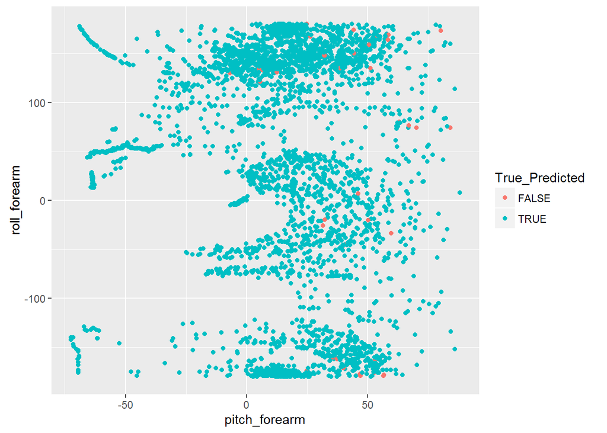

### Step 6: Prediction over test set with 20 observations

The model is employed to predict the quality of lifts with respect to 20 observations

```r
pred_final<-predict(modFit,testing)
pred_final
```

```
##  [1] B A B A A E D B A A B C B A E E A B B B
## Levels: A B C D E
```